# Biostat 203B Homework 3 - Mapping

EDA for Coronavirus Shiny App

George Dewey

## Import JHU CSSE Data

JHU’s CSSE maintains a data repository https://github.com/CSSEGISandData/COVID-19 tracking all COVID cases of the most recent outbreak. Data is broken down into `Confirmed`, `Deaths`, and `Recovered` cases and updated daily.

We import the most recent data as follows:

```r
(confirmed_raw = read_csv("https://raw.githubusercontent.com/CSSEGISandData/COVID-19/master/csse_covid_19_data/csse_covid_19_time_series/time_series_19-covid-Confirmed.csv"))
```

```
## # A tibble: 105 x 41
##    `Province/State` `Country/Region`   Lat  Long `1/22/20` `1/23/20` `1/24/20`
##    <chr>            <chr>            <dbl> <dbl>     <dbl>     <dbl>     <dbl>
##  1 Anhui            Mainland China    31.8  117.         1         9        15
##  2 Beijing          Mainland China    40.2  116.        14        22        36
##  3 Chongqing        Mainland China    30.1  108.         6         9        27
##  4 Fujian           Mainland China    26.1  118.         1         5        10
##  5 Gansu            Mainland China    36.1  104.         0         2         2
##  6 Guangdong        Mainland China    23.3  113.        26        32        53
##  7 Guangxi          Mainland China    23.8  109.         2         5        23
##  8 Guizhou          Mainland China    26.8  107.         1         3         3
##  9 Hainan           Mainland China    19.2  110.         4         5         8
## 10 Hebei            Mainland China    38.0  115.         1         1         2
## # … with 95 more rows, and 34 more variables: `1/25/20` <dbl>, `1/26/20` <dbl>,
## #   `1/27/20` <dbl>, `1/28/20` <dbl>, `1/29/20` <dbl>, `1/30/20` <dbl>,
## #   `1/31/20` <dbl>, `2/1/20` <dbl>, `2/2/20` <dbl>, `2/3/20` <dbl>,
## #   `2/4/20` <dbl>, `2/5/20` <dbl>, `2/6/20` <dbl>, `2/7/20` <dbl>,
## #   `2/8/20` <dbl>, `2/9/20` <dbl>, `2/10/20` <dbl>, `2/11/20` <dbl>,
## #   `2/12/20` <dbl>, `2/13/20` <dbl>, `2/14/20` <dbl>, `2/15/20` <dbl>,
## #   `2/16/20` <dbl>, `2/17/20` <dbl>, `2/18/20` <dbl>, `2/19/20` <dbl>,
## #   `2/20/20` <dbl>, `2/21/20` <dbl>, `2/22/20` <dbl>, `2/23/20` <dbl>,
## #   `2/24/20` <dbl>, `2/25/20` <dbl>, `2/26/20` <dbl>, `2/27/20` <dbl>
```

```r
(recovered_raw = read_csv("https://raw.githubusercontent.com/CSSEGISandData/COVID-19/master/csse_covid_19_data/csse_covid_19_time_series/time_series_19-covid-Recovered.csv"))
```

```
## # A tibble: 105 x 41
##    `Province/State` `Country/Region`   Lat  Long `1/22/20` `1/23/20` `1/24/20`
##    <chr>            <chr>            <dbl> <dbl>     <dbl>     <dbl>     <dbl>
##  1 Anhui            Mainland China    31.8  117.         0         0         0
##  2 Beijing          Mainland China    40.2  116.         0         0         1
##  3 Chongqing        Mainland China    30.1  108.         0         0         0
##  4 Fujian           Mainland China    26.1  118.         0         0         0
##  5 Gansu            Mainland China    36.1  104.         0         0         0
##  6 Guangdong        Mainland China    23.3  113.         0         2         2
##  7 Guangxi          Mainland China    23.8  109.         0         0         0
##  8 Guizhou          Mainland China    26.8  107.         0         0         0
##  9 Hainan           Mainland China    19.2  110.         0         0         0
## 10 Hebei            Mainland China    38.0  115.         0         0         0
## # … with 95 more rows, and 34 more variables: `1/25/20` <dbl>, `1/26/20` <dbl>,
## #   `1/27/20` <dbl>, `1/28/20` <dbl>, `1/29/20` <dbl>, `1/30/20` <dbl>,
## #   `1/31/20` <dbl>, `2/1/20` <dbl>, `2/2/20` <dbl>, `2/3/20` <dbl>,
## #   `2/4/20` <dbl>, `2/5/20` <dbl>, `2/6/20` <dbl>, `2/7/20` <dbl>,
## #   `2/8/20` <dbl>, `2/9/20` <dbl>, `2/10/20` <dbl>, `2/11/20` <dbl>,
## #   `2/12/20` <dbl>, `2/13/20` <dbl>, `2/14/20` <dbl>, `2/15/20` <dbl>,
## #   `2/16/20` <dbl>, `2/17/20` <dbl>, `2/18/20` <dbl>, `2/19/20` <dbl>,
## #   `2/20/20` <dbl>, `2/21/20` <dbl>, `2/22/20` <dbl>, `2/23/20` <dbl>,
## #   `2/24/20` <dbl>, `2/25/20` <dbl>, `2/26/20` <dbl>, `2/27/20` <dbl>
```

```r
(death_raw = read_csv("https://raw.githubusercontent.com/CSSEGISandData/COVID-19/master/csse_covid_19_data/csse_covid_19_time_series/time_series_19-covid-Deaths.csv"))
```

```
## # A tibble: 105 x 41
##    `Province/State` `Country/Region`   Lat  Long `1/22/20` `1/23/20` `1/24/20`
##    <chr>            <chr>            <dbl> <dbl>     <dbl>     <dbl>     <dbl>
##  1 Anhui            Mainland China    31.8  117.         0         0         0
##  2 Beijing          Mainland China    40.2  116.         0         0         0
##  3 Chongqing        Mainland China    30.1  108.         0         0         0
##  4 Fujian           Mainland China    26.1  118.         0         0         0
##  5 Gansu            Mainland China    36.1  104.         0         0         0
##  6 Guangdong        Mainland China    23.3  113.         0         0         0
##  7 Guangxi          Mainland China    23.8  109.         0         0         0
##  8 Guizhou          Mainland China    26.8  107.         0         0         0
##  9 Hainan           Mainland China    19.2  110.         0         0         0
## 10 Hebei            Mainland China    38.0  115.         0         1         1
## # … with 95 more rows, and 34 more variables: `1/25/20` <dbl>, `1/26/20` <dbl>,
## #   `1/27/20` <dbl>, `1/28/20` <dbl>, `1/29/20` <dbl>, `1/30/20` <dbl>,
## #   `1/31/20` <dbl>, `2/1/20` <dbl>, `2/2/20` <dbl>, `2/3/20` <dbl>,
## #   `2/4/20` <dbl>, `2/5/20` <dbl>, `2/6/20` <dbl>, `2/7/20` <dbl>,
## #   `2/8/20` <dbl>, `2/9/20` <dbl>, `2/10/20` <dbl>, `2/11/20` <dbl>,
## #   `2/12/20` <dbl>, `2/13/20` <dbl>, `2/14/20` <dbl>, `2/15/20` <dbl>,
## #   `2/16/20` <dbl>, `2/17/20` <dbl>, `2/18/20` <dbl>, `2/19/20` <dbl>,
## #   `2/20/20` <dbl>, `2/21/20` <dbl>, `2/22/20` <dbl>, `2/23/20` <dbl>,
## #   `2/24/20` <dbl>, `2/25/20` <dbl>, `2/26/20` <dbl>, `2/27/20` <dbl>
```

## Data Cleaning

The data is imported as longitudinal/time-series data. I will use Dr. Zhou’s framework to convert the imported CSVs into long format:

```r
confirmed = confirmed_raw %>%
  pivot_longer(-(`Province/State`:Long),
               names_to = "date",
               values_to = "confirmed") %>%
  mutate(date = mdy(date)) # convert string to date-time

confirmed
```

```
## # A tibble: 3,885 x 6
##    `Province/State` `Country/Region`   Lat  Long date       confirmed
##    <chr>            <chr>            <dbl> <dbl> <date>         <dbl>
##  1 Anhui            Mainland China    31.8  117. 2020-01-22         1
##  2 Anhui            Mainland China    31.8  117. 2020-01-23         9
##  3 Anhui            Mainland China    31.8  117. 2020-01-24        15
##  4 Anhui            Mainland China    31.8  117. 2020-01-25        39
##  5 Anhui            Mainland China    31.8  117. 2020-01-26        60
##  6 Anhui            Mainland China    31.8  117. 2020-01-27        70
##  7 Anhui            Mainland China    31.8  117. 2020-01-28       106
##  8 Anhui            Mainland China    31.8  117. 2020-01-29       152
##  9 Anhui            Mainland China    31.8  117. 2020-01-30       200
## 10 Anhui            Mainland China    31.8  117. 2020-01-31       237
## # … with 3,875 more rows
```

```r
recovered <- recovered_raw %>%
  pivot_longer(-(`Province/State`:Long),
               names_to = "date",
               values_to = "recovered") %>%
  mutate(date = mdy(date))

recovered
```

```
## # A tibble: 3,885 x 6
##    `Province/State` `Country/Region`   Lat  Long date       recovered
##    <chr>            <chr>            <dbl> <dbl> <date>         <dbl>
##  1 Anhui            Mainland China    31.8  117. 2020-01-22         0
##  2 Anhui            Mainland China    31.8  117. 2020-01-23         0
##  3 Anhui            Mainland China    31.8  117. 2020-01-24         0
##  4 Anhui            Mainland China    31.8  117. 2020-01-25         0
##  5 Anhui            Mainland China    31.8  117. 2020-01-26         0
##  6 Anhui            Mainland China    31.8  117. 2020-01-27         0
##  7 Anhui            Mainland China    31.8  117. 2020-01-28         0
##  8 Anhui            Mainland China    31.8  117. 2020-01-29         2
##  9 Anhui            Mainland China    31.8  117. 2020-01-30         2
## 10 Anhui            Mainland China    31.8  117. 2020-01-31         3
## # … with 3,875 more rows
```

```r
death <- death_raw %>%
  pivot_longer(-(`Province/State`:Long),
               names_to = "date",
               values_to = "death") %>%
  mutate(date = mdy(date))
death
```

```
## # A tibble: 3,885 x 6
##    `Province/State` `Country/Region`   Lat  Long date       death
##    <chr>            <chr>            <dbl> <dbl> <date>     <dbl>
##  1 Anhui            Mainland China    31.8  117. 2020-01-22     0
##  2 Anhui            Mainland China    31.8  117. 2020-01-23     0
##  3 Anhui            Mainland China    31.8  117. 2020-01-24     0
##  4 Anhui            Mainland China    31.8  117. 2020-01-25     0
##  5 Anhui            Mainland China    31.8  117. 2020-01-26     0
##  6 Anhui            Mainland China    31.8  117. 2020-01-27     0
##  7 Anhui            Mainland China    31.8  117. 2020-01-28     0
##  8 Anhui            Mainland China    31.8  117. 2020-01-29     0
##  9 Anhui            Mainland China    31.8  117. 2020-01-30     0
## 10 Anhui            Mainland China    31.8  117. 2020-01-31     0
## # … with 3,875 more rows
```

```r
covid <- confirmed %>%
  left_join(recovered) %>%
  left_join(death)
covid %>% print(width = Inf)
```

```
## # A tibble: 3,885 x 8
##    `Province/State` `Country/Region`   Lat  Long date       confirmed recovered
##    <chr>            <chr>            <dbl> <dbl> <date>         <dbl>     <dbl>
##  1 Anhui            Mainland China    31.8  117. 2020-01-22         1         0
##  2 Anhui            Mainland China    31.8  117. 2020-01-23         9         0
##  3 Anhui            Mainland China    31.8  117. 2020-01-24        15         0
##  4 Anhui            Mainland China    31.8  117. 2020-01-25        39         0
##  5 Anhui            Mainland China    31.8  117. 2020-01-26        60         0
##  6 Anhui            Mainland China    31.8  117. 2020-01-27        70         0
##  7 Anhui            Mainland China    31.8  117. 2020-01-28       106         0
##  8 Anhui            Mainland China    31.8  117. 2020-01-29       152         2
##  9 Anhui            Mainland China    31.8  117. 2020-01-30       200         2
## 10 Anhui            Mainland China    31.8  117. 2020-01-31       237         3
##    death
##    <dbl>
##  1     0
##  2     0
##  3     0
##  4     0
##  5     0
##  6     0
##  7     0
##  8     0
##  9     0
## 10     0
## # … with 3,875 more rows
```

## Plot cumulative Confirmed cases

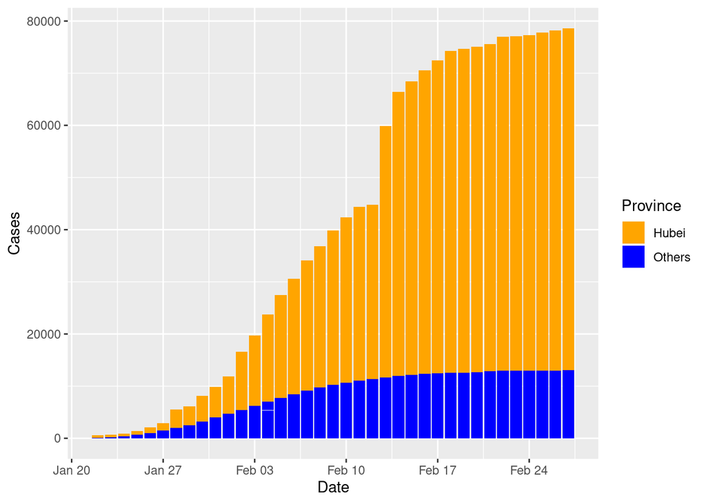

```r
covid %>% filter(`Country/Region` %in% c("Mainland China",
                                         "Macau",
                                         "Hong Kong",
                                         "Taiwan")) %>%
  mutate(isHubei = ifelse(`Province/State` == "Hubei", "Hubei", "Others")) %>%
  ggplot() +
  geom_col(aes(date, confirmed, fill = isHubei)) +
  labs(fill = "Province") +
  xlab("Date") +
  ylab("Cases") +
  scale_fill_manual(values = c("orange", "blue"))
```

## Write data to file for use in Shiny app

```r
write_csv(covid, "covid.csv")
```

We can get province-level incidence curves from this data.

## Other data sources

Other sources of data:  
- Tencent (in Chinese): https://news.qq.com/zt2020/page/feiyan.htm  
- R package `nCov2019`; install by `remotes::install_github("GuangchuangYu/nCov2019")`

## Explore nCov2019 Data

This data is from Chinese social media. While it should be mostly similar to the JHU data, we will keep it as an additional pane for comparison’s sake over the course of the outbreak.

```r
library(nCov2019)

hist = load_nCov2019(lang = "en")
head(summary(hist, ))
```

```
##         time province cum_confirm
## 1 2020-01-11    Hubei          41
## 2 2020-01-12    Hubei          41
## 3 2020-01-13    Hubei          41
## 4 2020-01-14    Hubei          41
## 5 2020-01-15    Hubei          41
## 6 2020-01-16    Hubei          45
```

The `nCov2019` data has province-level incidence data by day (like the JHU data).

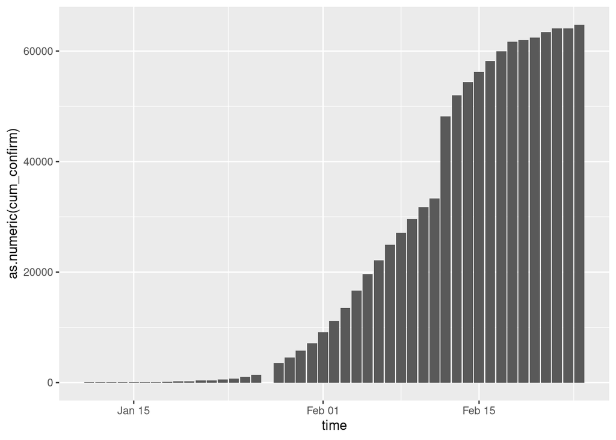

```r
ggplot(summary(hist, 'Hubei'), mapping = aes(time, as.numeric(cum_confirm))) +
  geom_col()
```

Looks like we can get province-level incidence plots from this as well.

## Mapping China provinces using `nCov2019`

`nCov2019` comes with a mapping module included (but only works with the up-to-date data).

```r
current = get_nCov2019(lang = "en")
require(chinamap)
cn = get_map_china()
```

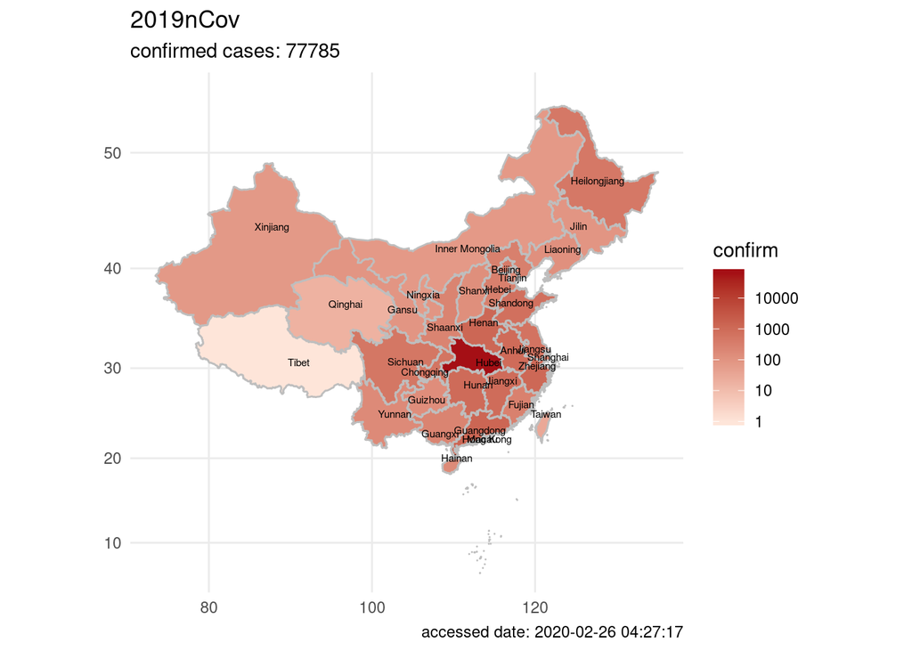

```r
cn$province = trans_province(cn$province)

plot(current, region = 'china', chinamap = cn, font.size = 2)
```

## Use GIS data from China

Donwload China GIS data from [here](https://uploads.cosx.org/2009/07/chinaprovinceborderdata_tar_gz.zip), unzip, and put in the working directory.

Read in the shape file into simple feature (SF) format. Replace the `NA` in `NAME` by Macau.

```r
library(sf)
chn_map = st_read("~/biostat-203b-2020-winter/bou2_4p.shp", as_tibble = TRUE) %>%
  mutate(NAME = iconv(NAME, from = "GBK"),
         BOU2_4M_ = as.integer(BOU2_4M_),
         BOU2_4M_ID = as.integer(BOU2_4M_ID)) %>%
  mutate(NAME = str_replace_na(NAME, replacement = "澳门特别行政区"))
chn_map
```

```
## Simple feature collection with 925 features and 7 fields
## geometry type:  POLYGON
## dimension:      XY
## bbox:           xmin: 73.44696 ymin: 6.318641 xmax: 135.0858 ymax: 53.55793
## epsg (SRID):    NA
## proj4string:    NA
## # A tibble: 925 x 8
##      AREA PERIMETER BOU2_4M_ BOU2_4M_ID ADCODE93 ADCODE99 NAME
##  *  <dbl>     <dbl>    <int>      <int>    <int>    <int> <chr>
##  1  54.4     68.5          2         23   230000   230000 黑龙江省…
##  2 129.     130.           3         15   150000   150000 内蒙古自…
##  3 176.      84.9          4         65   650000   650000 新疆维吾…
##  4  21.3     41.2          5         22   220000   220000 吉林省…
##  5  15.6     38.4          6         21   210000   210000 辽宁省…
##  6  41.5     76.8          7         62   620000   620000 甘肃省…
##  7  19.5     44.9          8         13   130000   130000 河北省…
##  8   1.73     8.50         9         11   110000   110000 北京市…
##  9   0        0.088       10        292   210000   210000 辽宁省…
## 10   0        0.047       11        292   210000   210000 辽宁省…
## # … with 915 more rows, and 1 more variable: geometry <POLYGON>
```

There are about 34 provinces in China, why there are 925 areas?

```r
chn_map %>%
  count(NAME) %>%
  print(n = Inf)
```

```
## Simple feature collection with 34 features and 2 fields
## geometry type:  GEOMETRY
## dimension:      XY
## bbox:           xmin: 73.44696 ymin: 6.318641 xmax: 135.0858 ymax: 53.55793
## epsg (SRID):    NA
## proj4string:    NA
## # A tibble: 34 x 3
##    NAME             n                                                   geometry
##  * <chr>        <int>                                                 <GEOMETRY>
##  1 上海市          12 MULTIPOLYGON (((121.414 30.6952, 121.415 30.69756, 121.41…
##  2 云南省           1 POLYGON ((98.65588 28.83075, 98.65788 28.8333, 98.66165 2…
##  3 内蒙古自治区     1 POLYGON ((121.4884 53.33265, 121.4974 53.32104, 121.5004 …
##  4 北京市           1 POLYGON ((117.496 40.66534, 117.4992 40.64039, 117.4938 4…
##  5 台湾省          57 MULTIPOLYGON (((120.8155 21.75681, 120.8174 21.75765, 120…
##  6 吉林省           1 POLYGON ((123.171 46.24668, 123.2186 46.26945, 123.2394 4…
```

[output cut: 28 more lines]

`ggplot2` can plot SF data using `geom_sf` function:

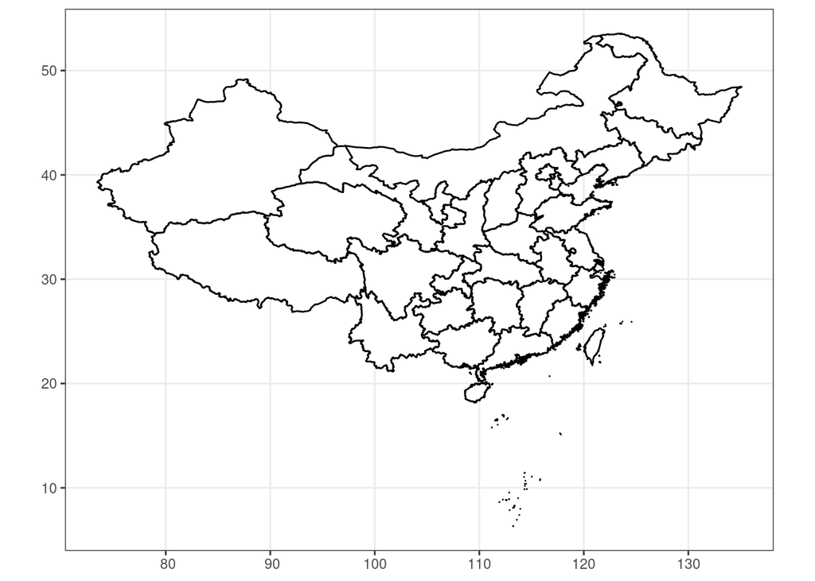

```r
chn_map %>%
  ggplot() +
  geom_sf(mapping = aes(geometry = geometry), color = "black", fill = "white") +
  theme_bw()
```

These are the provinces available from the JHU data.

```r
covid %>%
  filter(`Country/Region` %in% c("Mainland China", "Macau", "Hong Kong", "Taiwan")) %>%
  distinct(`Province/State`, `Country/Region`) %>%
  print(n = Inf)
```

```
## # A tibble: 34 x 2
##    `Province/State` `Country/Region`
##    <chr>            <chr>
##  1 Anhui            Mainland China
##  2 Beijing          Mainland China
##  3 Chongqing        Mainland China
##  4 Fujian           Mainland China
##  5 Gansu            Mainland China
##  6 Guangdong        Mainland China
##  7 Guangxi          Mainland China
##  8 Guizhou          Mainland China
##  9 Hainan           Mainland China
## 10 Hebei            Mainland China
## 11 Heilongjiang     Mainland China
## 12 Henan            Mainland China
```

[output cut: 22 more lines]

Use Dr. Zhou’s function to convert Chinese province names to English

```r
translate <- function(x) {
  sapply(x, function(chn_name) {
    if (str_detect(chn_name, "澳门")) {
      eng_name <- "Macau"
    } else if (str_detect(chn_name, "台湾")) {
      eng_name <- "Taiwan"
    } else if (str_detect(chn_name, "上海")) {
      eng_name <- "Shanghai"
    } else if (str_detect(chn_name, "云南")) {
      eng_name <- "Yunnan"
    } else if (str_detect(chn_name, "内蒙古")) {
      eng_name <- "Inner Mongolia"
    } else if (str_detect(chn_name, "北京")) {
      eng_name <- "Beijing"
    } else if (str_detect(chn_name, "台湾")) {
      eng_name <- "Taiwan"
    } else if (str_detect(chn_name, "吉林")) {
      eng_name <- "Jilin"
    } else if (str_detect(chn_name, "四川")) {
      eng_name <- "Sichuan"
    } else if (str_detect(chn_name, "天津")) {
      eng_name <- "Tianjin"
    } else if (str_detect(chn_name, "宁夏")) {
      eng_name <- "Ningxia"
    } else if (str_detect(chn_name, "安徽")) {
      eng_name <- "Anhui"
    } else if (str_detect(chn_name, "山东")) {
      eng_name <- "Shandong"
    } else if (str_detect(chn_name, "山西")) {
      eng_name <- "Shanxi"
    } else if (str_detect(chn_name, "广东")) {
      eng_name <- "Guangdong"
    } else if (str_detect(chn_name, "广西")) {
      eng_name <- "Guangxi"
    } else if (str_detect(chn_name, "新疆")) {
      eng_name <- "Xinjiang"
    } else if (str_detect(chn_name, "江苏")) {
      eng_name <- "Jiangsu"
    } else if (str_detect(chn_name, "江西")) {
      eng_name <- "Jiangxi"
    } else if (str_detect(chn_name, "河北")) {
      eng_name <- "Hebei"
    } else if (str_detect(chn_name, "河南")) {
      eng_name <- "Henan"
    } else if (str_detect(chn_name, "浙江")) {
      eng_name <- "Zhejiang"
    } else if (str_detect(chn_name, "海南")) {
      eng_name <- "Hainan"
    } else if (str_detect(chn_name, "湖北")) {
      eng_name <- "Hubei"
    } else if (str_detect(chn_name, "湖南")) {
      eng_name <- "Hunan"
    } else if (str_detect(chn_name, "甘肃")) {
      eng_name <- "Gansu"
    } else if (str_detect(chn_name, "福建")) {
      eng_name <- "Fujian"
    } else if (str_detect(chn_name, "西藏")) {
      eng_name <- "Tibet"
    } else if (str_detect(chn_name, "贵州")) {
      eng_name <- "Guizhou"
    } else if (str_detect(chn_name, "辽宁")) {
      eng_name <- "Liaoning"
    } else if (str_detect(chn_name, "重庆")) {
      eng_name <- "Chongqing"
    } else if (str_detect(chn_name, "陕西")) {
      eng_name <- "Shanxi"
    } else if (str_detect(chn_name, "青海")) {
      eng_name <- "Qinghai"
    } else if (str_detect(chn_name, "香港")) {
      eng_name <- "Hong Kong"
    } else if (str_detect(chn_name, "黑龙江")) {
      eng_name <- "Heilongjiang"
    } else {
      eng_name <- chn_name # don't translate if no correspondence
    }
    return(eng_name)
  })
}
```

## Create a new variable `NAME_ENG` converting Chinese placenames to English

```r
chn_prov = chn_map %>%
  count(NAME) %>%
  mutate(NAME_ENG = translate(NAME)) # translate function is vectorized
chn_prov %>% print(n = Inf)
```

```
## Simple feature collection with 34 features and 3 fields
## geometry type:  GEOMETRY
## dimension:      XY
## bbox:           xmin: 73.44696 ymin: 6.318641 xmax: 135.0858 ymax: 53.55793
## epsg (SRID):    NA
## proj4string:    NA
## # A tibble: 34 x 4
##    NAME           n                                          geometry NAME_ENG
##  * <chr>      <int>                                        <GEOMETRY> <chr>
##  1 上海市        12 MULTIPOLYGON (((121.414 30.6952, 121.415 30.6975… Shanghai
##  2 云南省         1 POLYGON ((98.65588 28.83075, 98.65788 28.8333, 9… Yunnan
##  3 内蒙古自治区…     1 POLYGON ((121.4884 53.33265, 121.4974 53.32104, … Inner Mon…
##  4 北京市         1 POLYGON ((117.496 40.66534, 117.4992 40.64039, 1… Beijing
##  5 台湾省        57 MULTIPOLYGON (((120.8155 21.75681, 120.8174 21.7… Taiwan
##  6 吉林省         1 POLYGON ((123.171 46.24668, 123.2186 46.26945, 1… Jilin
```

[output cut: 28 more lines]

```r
write_csv(chn_prov, "./covid_map/provs.csv")
```

## Plotting 2019-nCoV incidence

Plot confirmed cases on a specific date

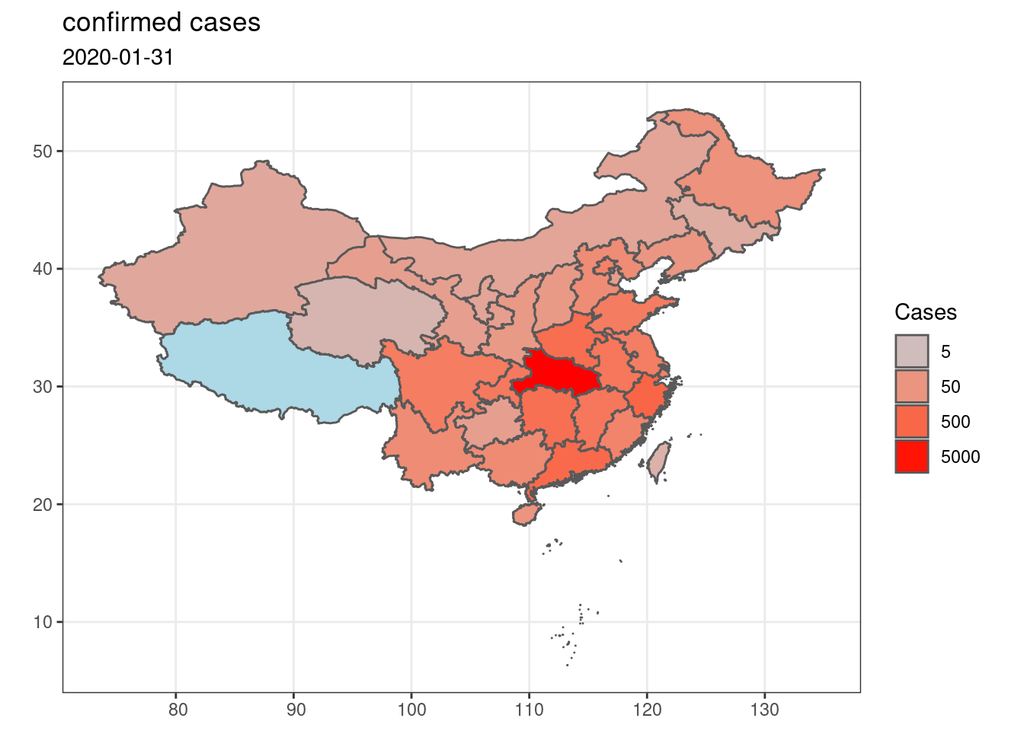

```r
plotdate = "2020-01-31"

count <- "confirmed"

covid %>%
  filter(`Country/Region` %in% c("Mainland China", "Macau", "Hong Kong", "Taiwan")) %>%
  filter(date == plotdate) %>%
  group_by(`Province/State`) %>%
  top_n(1, date) %>% # take the latest count on that date
  right_join(chn_prov, by = c("Province/State" = "NAME_ENG")) %>%
  ggplot() +
  geom_sf(mapping = aes(fill = !!sym(count), geometry = geometry)) +
  scale_fill_gradient(name = "Cases",
                      trans = "log10",
                      breaks = c(5, 50, 500, 5000, 50000, 100000),
                      labels = c(5, 50, 500, 5000, 50000, 100000),
                      guide = "legend",
                      low = "lightblue",
                      high = "red") +
  theme_bw() +
  labs(title = str_c(count, " cases"), subtitle = plotdate)
```